# Predicting Exoplanets Using Big Data Techniques: A Classification Task

## 11. Exoplanet Prediction on Current Exoplanet Candidates

The final step in the implementation of this project was to apply the best machine learning model, the Random Forest, to real-world data. Specifically, this involved predicting the classification of current candidate exoplanets—whether they are false positives or confirmed exoplanets. This implementation underscores the importance of the project by demonstrating its practical applicability to real scientific data, potentially aiding in the discovery and validation of new exoplanets. The predictive power of machine learning in this context can significantly streamline the classification process, reducing the need for manual and time-consuming investigations.

However, it is important to note that while the Random Forest model performed well on the training and test datasets, its predictions on the real-world data should be interpreted with caution. Machine learning models, including Random Forests, are only as good as the data they are trained on, and any biases or limitations in the training data may carry over to the predictions. For instance, the model might not account for nuances or unseen patterns in the candidate exoplanet data that were not present in the training set.

Moreover, real-world predictions of exoplanet classification rely on a range of observational and astrophysical factors, and while machine learning provides an efficient and accurate method for classification, it cannot replace the need for subsequent scientific validation through further observations. Thus, these predictions serve as a helpful tool to prioritise candidates for follow-up but should not be taken as definitive without additional investigation with external data sources and expert review to ensure their reliability and accuracy.

```python
def make_predictions(model: PipelineModel, data: DataFrame, features_col: str = "features", prediction_col: str = "prediction") -> DataFrame:
    """
    Function to pass data into an already built machine learning model for prediction.

    Parameters:
    ----------
    model : PipelineModel
        A pre-trained machine learning model in PySpark

    data : DataFrame
        The input data on which predictions are to be made. The DataFrame must have a column for features, typically created through a transformation pipeline.

    features_col : str, optional, default="features"
        The name of the column in the input DataFrame containing the feature vectors. This column will be used by the model to make predictions.

    prediction_col : str, optional, default="prediction"
        The name of the column in the output DataFrame that will store the prediction results.

    Returns:
    -------
    DataFrame
        A new DataFrame with predictions, containing all the original columns along with a new column for predictions.
    """
    # Check if the model and data are valid inputs
    if not isinstance(model, PipelineModel):
        raise TypeError("The 'model' must be a PySpark PipelineModel.")

    if not isinstance(data, DataFrame):
        raise TypeError("The 'data' must be a PySpark DataFrame.")

    # Ensure that the features column exists in the input DataFrame
    if features_col not in data.columns:
        raise ValueError(f"Column '{features_col}' not found in the input DataFrame.")

    # Apply the model to the data to make predictions
    predictions = model.transform(data)

    # Select the relevant columns: original data and prediction column
    return predictions.select("*", prediction_col)
```

```python
# Converting the candidate pandas dataframe to a Pyspark dataframe
candidate_data = sq.createDataFrame(df_cd)

# Combining raw feature columns into a 'features' column
assembler = VectorAssembler(inputCols=important_features, outputCol="assembled_features")
prediction_data = assembler.transform(candidate_data)

# Apply the model and get predictions
predictions = rf_model.transform(prediction_data)

# Print the schema to verify the output columns
# predictions.printSchema()

# If the 'prediction' column exists, use it. Otherwise, adjust accordingly.
if "prediction" in predictions.columns:
    random_forest_predictions = make_predictions(rf_model, prediction_data, features_col="assembled_features", prediction_col="prediction")
else:
    # Use the available prediction-related column like 'rawPrediction' or 'probability'
    random_forest_predictions = make_predictions(rf_model, prediction_data, features_col="assembled_features", prediction_col="rawPrediction")
```

```python
# Convert to pandas dataframe
rf_pred = random_forest_predictions.toPandas()

# Drop the added features column
rf_pred = rf_pred.drop(['assembled_features', 'rawPrediction'], axis=1)

# Replace 0 with 'FALSE POSITIVE' and 1 with 'CONFIRMED' in the 'predicted_label' column
rf_pred['predicted_label'] = rf_pred['predicted_label'].replace({0 : 'FALSE POSITIVE', 1 : 'CONFIRMED'})

# View the dataframe
rf_pred.head()
```

|  | koi_score | koi_fpflag_nt | koi_fpflag_ss | koi_fpflag_co | koi_fpflag_ec | koi_prad | koi_period | koi_duration | koi_depth | koi_srho | ... | koi_srad | koi_smass | koi_ror | koi_num_transits | koi_tce_plnt_num | koi_dor | koi_disposition | features | probability | predicted_label |
| --- | --- | --- | --- | --- | --- | --- | --- | --- | --- | --- | --- | --- | --- | --- | --- | --- | --- | --- | --- | --- | --- |
| 0 | -0.483246 | 0.0 | 0.0 | 0.0 | 0.0 | 0.597066 | 0.267138 | -0.523712 | 5.297507 | 2.032300 | ... | -0.231026 | -0.095041 | 0.865192 | -0.414406 | 0.0 | 0.753053 | CANDIDATE | (-0.48324562968804785, 0.0, 0.0, 0.0, 5.297507... | [0.8605400009895087, 0.1394599990104914] | FALSE POSITIVE |
| 1 | 0.520774 | 0.0 | 0.0 | 0.0 | 0.0 | 0.247504 | 0.807411 | -0.112172 | 2.962587 | 0.277714 | ... | -0.376147 | -1.115702 | 0.432889 | -0.474465 | 0.0 | 0.777579 | CANDIDATE | (0.5207744708144647, 0.0, 0.0, 0.0, 2.96258664... | [0.012505626829781583, 0.9874943731702184] | CONFIRMED |
| 2 | 0.514744 | 0.0 | 0.0 | 0.0 | 0.0 | 0.836189 | -0.066142 | -0.842618 | 0.052437 | 2.476976 | ... | -0.402836 | -0.553719 | 1.381332 | -0.078076 | 1.0 | 0.248224 | CANDIDATE | [0.5147443200606958, 0.0, 0.0, 0.0, 0.05243742... | [0.012505626829781583, 0.9874943731702184] | CONFIRMED |
| 3 | 0.392131 | 0.0 | 0.0 | 0.0 | 0.0 | -0.095649 | -0.166316 | -0.171827 | -0.219808 | -0.185378 | ... | 0.134279 | -0.177686 | -0.113948 | 0.489480 | 2.0 | -0.204486 | CANDIDATE | [0.3921312547340627, 0.0, 0.0, 0.0, -0.2198082... | [0.0195241394531426, 0.9804758605468574] | CONFIRMED |
| 4 | 0.521779 | 0.0 | 0.0 | 0.0 | 0.0 | 0.258351 | 0.011288 | -0.073904 | 2.699685 | -0.214507 | ... | -0.284404 | -0.409091 | 0.410867 | -0.195191 | 0.0 | -0.079281 | CANDIDATE | (0.5217794959400929, 0.0, 0.0, 0.0, 2.69968471... | [0.012505626829781583, 0.9874943731702184] | CONFIRMED |

5 rows × 26 columns

```
CONFIRMED         1151
FALSE POSITIVE     831
Name: predicted_label, dtype: int64
```

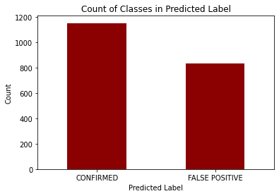

```python
# Count the occurrences of each class in the 'predicted_label' column
class_counts = rf_pred['predicted_label'].value_counts()

print(class_counts)

# Create a bar plot
class_counts.plot(kind='bar', color='darkred')

# Add title and labels
plt.title('Count of Classes in Predicted Label')
plt.xticks(rotation=0)
plt.xlabel('Predicted Label')
plt.ylabel('Count')

# Show the plot
plt.show()
```

## 12. Summary and Conclusion

### 12.1 Summary

This project aimed to classify exoplanet candidates using a variety of machine learning models. The dataset was preprocessed, normalised, and key features were selected based on domain knowledge and exploratory data analysis. A variety of models were implemented, including Naive Bayes, Logistic Regression, Support Vector Machine, Random Forest, and a Multilayer Perceptron. These models were evaluated on metrics such as accuracy, precision, recall, F1 score, and area under the ROC curve. Among the models, Random Forest performed the best with an accuracy of 98.8% and an AUC of 1.0, making it the selected model for further use.

### 12.2 Conclusion

In conclusion, the implementation of machine learning in exoplanet classification has demonstrated strong potential, with the Random Forest model emerging as a highly accurate tool for classifying exoplanet candidates. The project highlights the power of machine learning algorithms in analyzing complex astronomical datasets and making predictions that can guide further scientific investigation. However, while the model's performance on real-world data is promising, the predictions should be validated through additional scientific methods and observations to ensure their accuracy and reliability.

Ultimately, this project illustrates how machine learning can be a valuable tool in the field of astronomy, particularly in the classification of exoplanet candidates. By improving the efficiency and accuracy of this process, machine learning models can significantly contribute to the discovery of new exoplanets, enhancing our understanding of distant worlds.

Kindly see the third component of this project for more in-depth analysis of the results, discussion and conclusion.

## 13. References

1. Ansdell, M., Ioannou, Y., Osborn, H. P., Sasdelli, M., Smith, J. C., Caldwell, D. A., … & Angerhausen, D. (2018). Scientific domain knowledge improves exoplanet transit classification with deep learning. The Astrophysical Journal Letters, 869(1), L7. https://doi.org/10.3847/2041-8213/aaf23b.
2. Basak, S., Agrawal, S., Saha, S., Theophilus, A., Bora, K., Deshpande, G., … & Murthy, J. (2018). Habitability classification of exoplanets: a machine learning insight.. https://doi.org/10.48550/arxiv.1805.08810
3. Forestano, R. T., Matchev, K. T., Matcheva, K., & Unlu, E. B. (2023). Searching for novel chemistry in exoplanetary atmospheres using machine learning for anomaly detection. The Astrophysical Journal, 958(2), 106. https://doi.org/10.3847/1538-4357/ad0047.
4. Jin, Y., Yang, L., & Chiang, C. (2022). Identifying exoplanets with machine learning methods: a preliminary study. International Journal on Cybernetics &Amp; Informatics, 11(2), 31-42. https://doi.org/10.5121/ijci.2022.110203.
5. Pham, D. and Kaltenegger, L. (2022). Follow the water: finding water, snow and clouds on terrestrial exoplanets with photometry and machine learning.. https://doi.org/10.48550/arxiv.2203.04201. Sasmita Kumari Nayak (2024). Classification of kepler exoplanet searching from galaxy using machine learning model. World Journal of Advanced Research and Reviews, 21(1), 227-230. https://doi.org/10.30574/wjarr.2024.21.1.0012.
6. Shallue, C. J. and Vanderburg, A. (2018). Identifying exoplanets with deep learning: a five-planet resonant chain around kepler-80 and an eighth planet around kepler-90. The Astronomical Journal, 155(2), 94. https://doi.org/10.3847/1538-3881/aa9e09
7. Singh, H. V., Agarwal, N., & Yadav, A. (2024). A novel methodology for hunting exoplanets in space using machine learning. EAI Endorsed Transactions on Internet of Things, 10. https://doi.org/10.4108/eetiot.5331.
8. Ulmer-Moll, S., Santos, N. C., Figueira, P., Brinchmann, J., & Faria, J. P. (2019). Beyond the exoplanet mass-radius relation. Astronomy &Amp; Astrophysics, 630, A135. https://doi.org/10.1051/0004-6361/201936049.

Non-academic Referencing:

1. ChatGPT, OpenAI, 2024: For assistance with restructuring paragraphs for better coherence, more scientific tone and grammatical correctness.

Thank you for reading this notebook :)